# Week 8 · Class 1

Sampling and Uncertainty & Statistical Significance

Sean Westwood

Segment A — Sampling and Uncertainty

## In Today’s Class

**Segment A — Sampling and Uncertainty**

- Understanding populations vs. samples
- Randomization revisited: how chance creates balanced groups
- Why sampling creates uncertainty
- How sample size affects confidence
- Margin of error and its calculation
- A first look at the t-distribution

**Segment B — What is Statistical Significance?**

- Understanding hypothesis testing step by step
- Null and alternative hypotheses
- P-values and what they really mean
- When to reject the null hypothesis

## Why Do Polls Disagree?

Three polls are released the same week. All ask the same question about the same population:

- Poll A: 43% approval
- Poll B: 48% approval
- Poll C: 46% approval

Which one is right? How do we know how much to trust any of them?

*That’s what today is about.*

Populations vs. Samples

## What is a Population?

**Population**: The complete group you want to study

**Examples in Political Science**:

- All registered voters in the United States
- All members of Congress
- All citizens
- All countries in the world

**Key Characteristics**:

- Has a true, fixed value for any measure (population parameter)
- Usually impossible or impractical to study completely
- Denoted with Greek letters ($\mu$ for mean, $\sigma$ for standard deviation)

## What is a Sample?

**Sample**: A subset of the population that we actually observe

**Examples**:

- 1,000 voters surveyed by Gallup
- 100 members of Congress interviewed
- 500 citizens polled before an election

**Key Characteristics**:

- Gives us a practical estimate of the population parameter

## An Analogy: Tasting Soup

You’re cooking a giant pot of soup and want to know if it needs more salt.

- **Population** = the whole pot
- **Sample** = the spoonful you taste
- **μ** = how salty the pot actually is
- **x̄** = how salty your spoonful tastes

You stir the pot and take a spoonful. A different spoonful would taste slightly different — but if the pot is well-stirred, any spoonful tells you something useful.

## Every Sample Is Different

**The Core Problem**: Different samples from the same population give different results

|  | Sample 1 | Sample 2 | Sample 3 | Sample 4 |
| --- | --- | --- | --- | --- |
| **Size** | 1,000 voters | 1,000 voters | 1,000 voters | 1,000 voters |
| **Estimate** | 48% | 55% | 30% | 49% |

Which one is “right”? How do we know what the true population value is?

## Where Does Variation Come From?

**Why do different samples give different results?**

We’ll explore three key sources:

1. Random Selection
2. Population Heterogeneity
3. Sample Size Limitations

## Random Selection

**Each sample includes different people by chance**

- Every time we sample, we get a different random draw
- No two samples are identical
- This randomness is unavoidable

**Example**: Drawing 5 samples of n=100 from the same population gives 5 different estimates

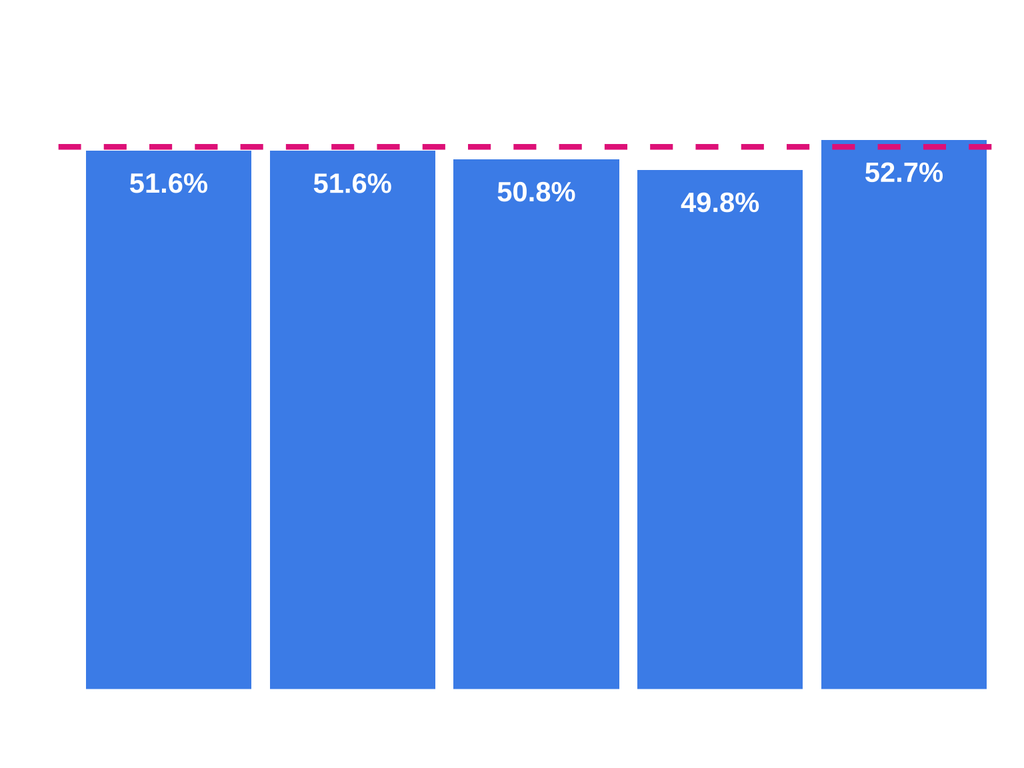

## People Are Different

**The population itself is diverse**

- People differ in their characteristics
- Some are strongly supportive, others strongly opposed
- Most fall somewhere in the middle

**Impact**: Some samples randomly capture more of one type than another

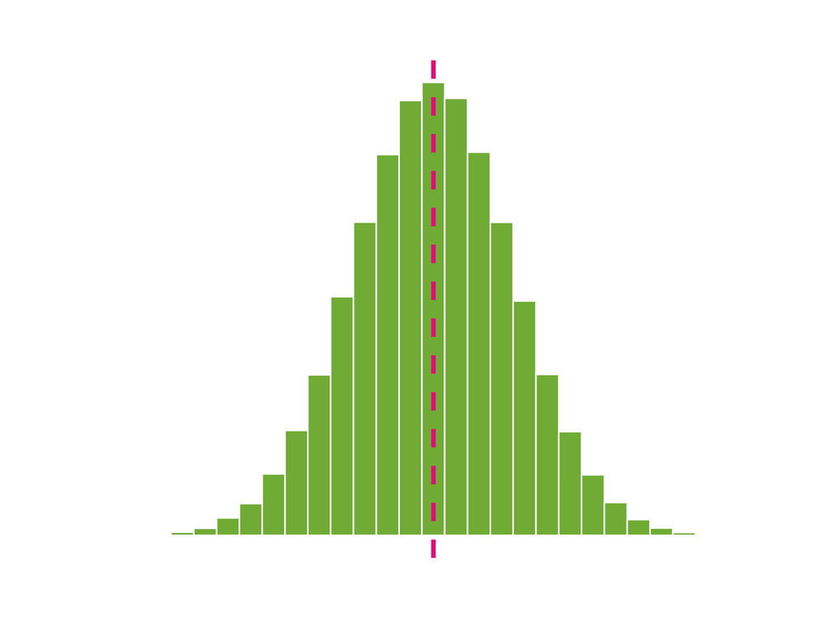

## Small Samples Swing More

**Smaller samples are more susceptible to variation**

- Larger samples better represent the population
- But even large samples vary somewhat
- The key is understanding how much variation to expect

**The trade-off**: Precision vs. cost and feasibility

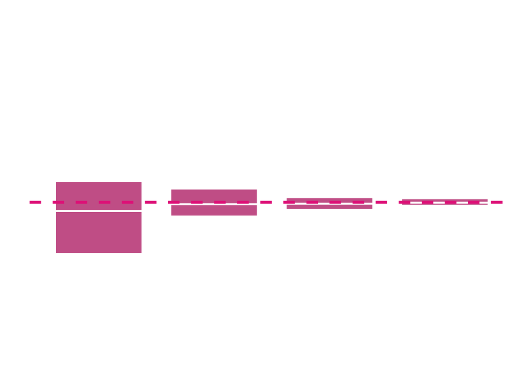

## Sampling Variation Is Predictable

Sampling variation is *random* but *predictable*

- We can’t eliminate it
- But we can measure and account for it

“If every sample gives a different answer, how can we trust any of them?”

This is the most common reaction — and it’s wrong. The variation is random and predictable. That’s exactly what lets us measure how confident we should be.

## When Two Samples Disagree

A researcher takes two random samples from the same population:

- Sample A (n = 50): mean = 48%
- Sample B (n = 50): mean = 54%

Does this mean one sample is “wrong”?

**No.** Both are legitimate random draws — a 6-point gap between two n = 50 samples is ordinary chance variation. The rest of today is about knowing *how much* variation to expect.

The Sample Mean Is Unbiased

## Sample Means Cluster Around the Truth

**The Problem We Just Saw**: Different samples give different estimates

- Even though individual samples vary, if we randomly select them, they cluster around the true population value
- The sample mean is **unbiased**: on average, it equals the population mean
- With larger samples, estimates get closer to the true value

## Averaging Over Thousands of Samples

Imagine taking not 1 sample, not 10, but thousands of samples — and calculating the mean of each.

- Some sample means will be a little too high
- Some will be a little too low
- But the *average of all those sample means* lands right on the true population value

## The Unbiased Estimator

$$E[\bar{x}] = \mu$$

- $\bar{x}$ = the mean from one sample (what we calculate)
- $E[\bar{x}]$ = the average of $\bar{x}$ across many samples
- $\mu$ = the true population mean
- The equation says: the average sample mean equals the true mean

This is why the sample mean is called an **unbiased estimator**.

## Population Mean vs. Sample Mean

**Population Mean (μ)**: The true average in the population

**Sample Mean (x̄)**: The average in our sample

**Why This Matters**: The sample mean is our best guess of the population mean, but it’s not perfect

## 52.4% vs. 52.0%: Close Enough?

Consider the following example:

- True Population Mean: 52.01%
- Sample Mean (n=1000): 52.41%

**Close enough?**

**What if we took a different sample?**

- Sample Mean (n=1000): 51.12%

**Close enough?**

**How do we know if the difference is “close enough”?**

## When Is an Estimate “Close”?

| Research Question | Population Mean (μ) | Sample Mean (x̄) | Difference | Assessment |
| --- | --- | --- | --- | --- |
| Presidential Approval | 52.0% | 52.4% | +0.4% | **Close** |
| Support for Policy X | 45.0% | 44.8% | -0.2% | **Very Close** |
| Congressional Approval | 28.0% | 35.2% | +7.2% | **Far** |
| Trust in Media | 38.0% | 31.5% | -6.5% | **Far** |
| Voter Turnout Intent | 67.0% | 68.1% | +1.1% | **Close** |
| Party Identification (% Dem) | 33.0% | 38.5% | +5.5% | **Far** |

**The Critical Question**: How do we systematically determine what counts as “close” vs. “far”?

**The Answer**: We need to understand and measure sampling uncertainty

Sampling Uncertainty

## Randomization Revisited

In Week 5 we said random assignment makes treatment and control groups **similar on average** — and we took that on faith.

- Today we have the tools to see *exactly* what “on average” means
- The same logic that makes randomization work is what makes **sampling** work

**Random assignment and random sampling are the same idea**: let chance build the groups, and chance variation becomes predictable.

## Why Random Assignment Matters

**Without random assignment, groups can be very different:**

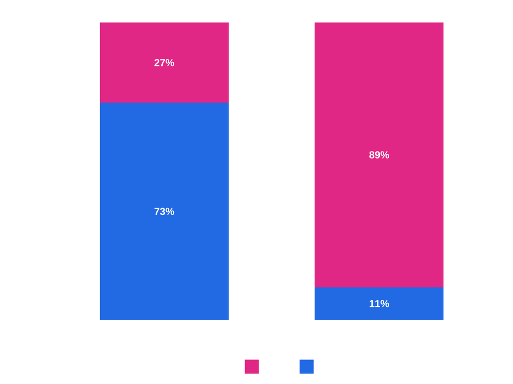

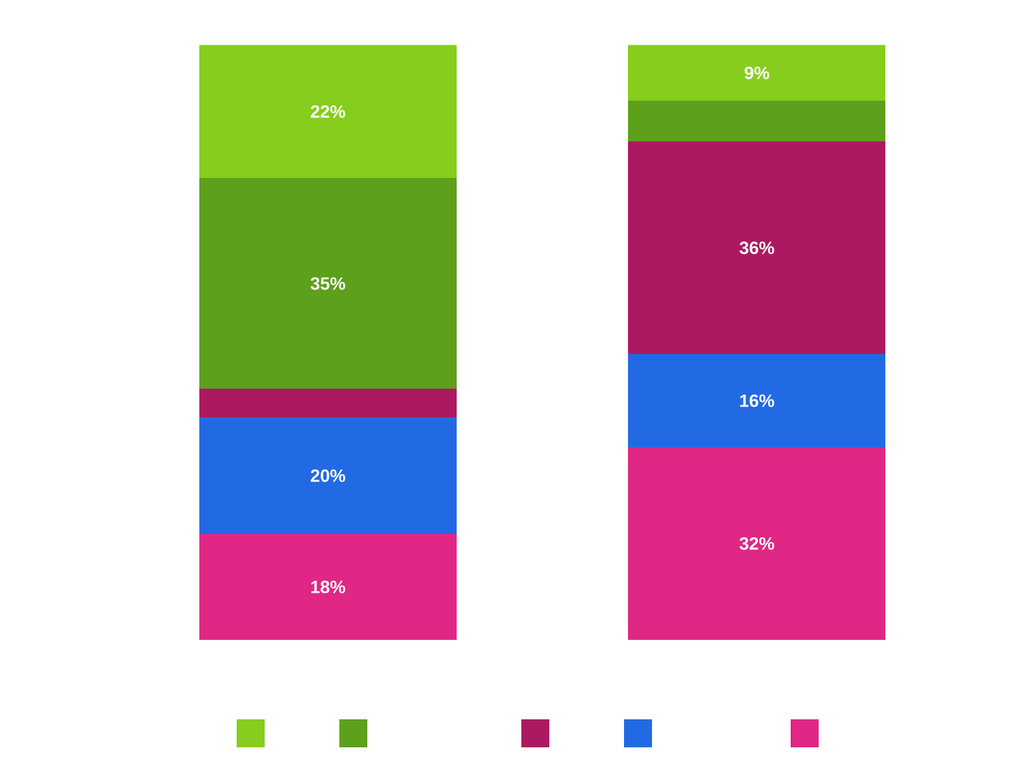

## How Random Assignment Works

**Random assignment**: Each subject has an equal chance of being assigned to any group

Population (8 people)

Blue Blue Red Blue Red Red Red Blue

▼

**Coin flip for each person**  
Heads → Group 1 · Tails → Group 2

▼▼

**Group 1 (Treatment)**

**Group 2 (Control)**

**Key insight**: Random assignment makes treatment and control groups statistically identical on average

## Random Assignment: Unobserved Characteristics

**In practice, we often don’t know people’s characteristics beforehand**

Population (8 people)

?Unknown ?Unknown ?Unknown ?Unknown ?Unknown ?Unknown ?Unknown ?Unknown

▼

**Coin flip for each person**  
Heads → Group 1 · Tails → Group 2

▼▼

**Group 1 (Treatment)**

2 Green + 2 Orange

**Group 2 (Control)**

2 Green + 2 Orange

**Key insight**: Random assignment works even when we don’t know characteristics in advance - it automatically balances groups across all traits (known and unknown)!

## Random Assignment: Individual Trial Variation

Random assignment doesn’t *guarantee* perfectly balanced characteristics in any single trial (100 people, 50 purple/50 pink, randomly assigned to groups of 50 each)

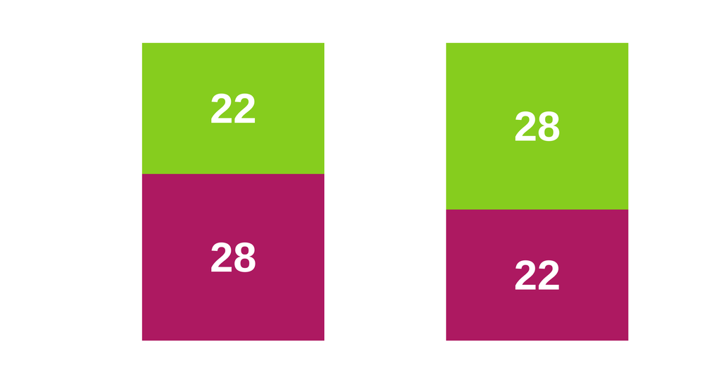

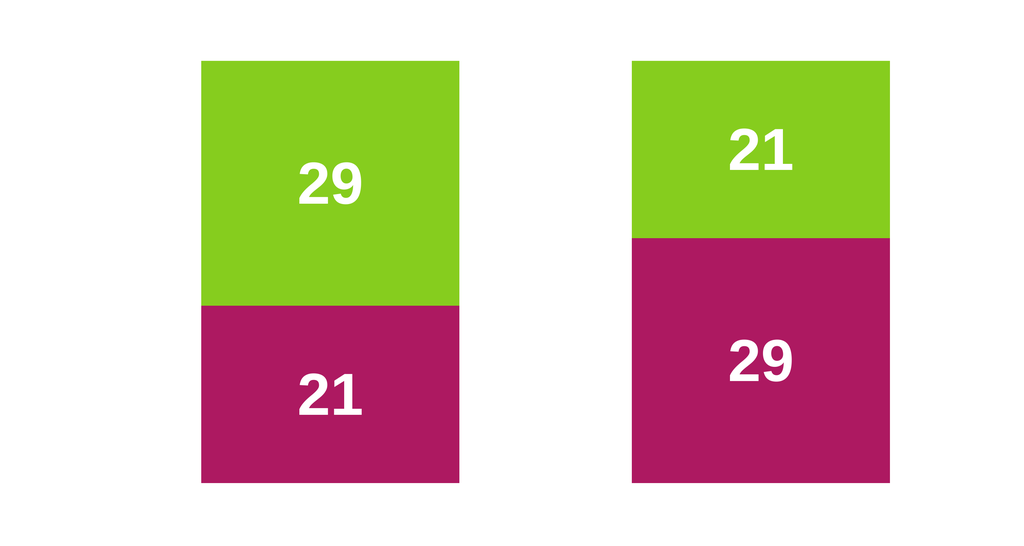

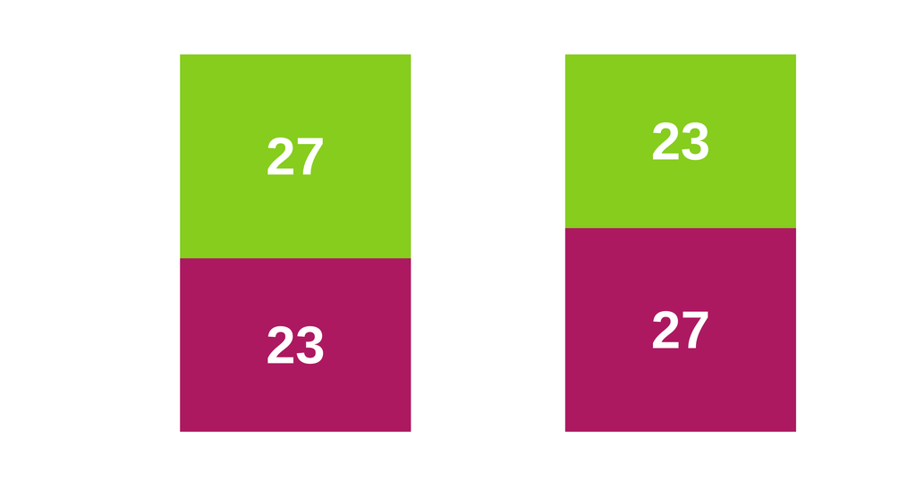

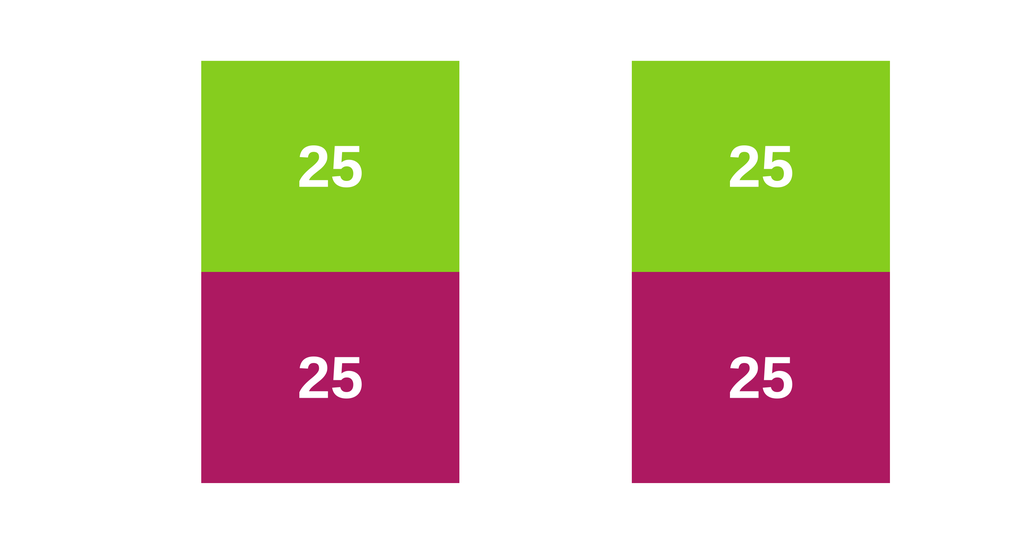

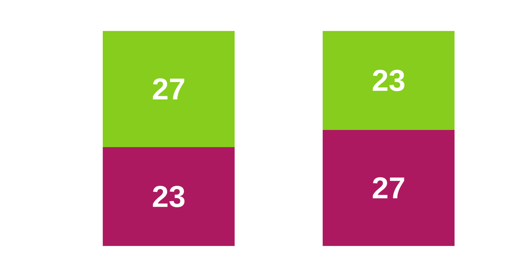

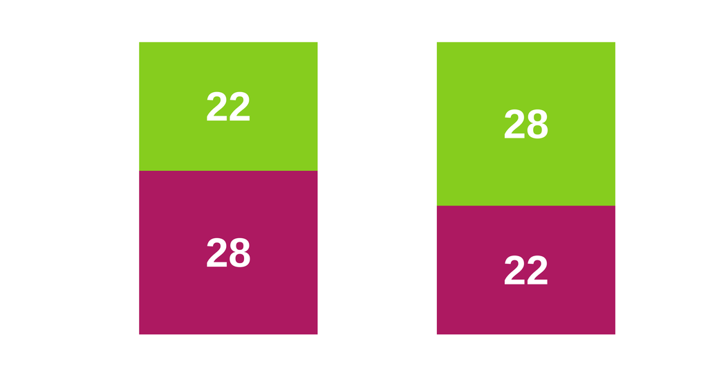

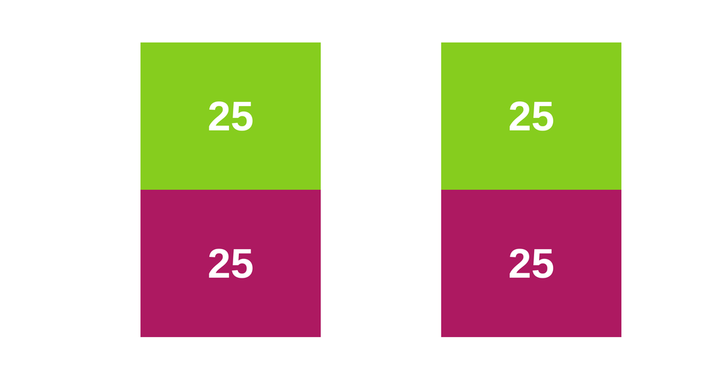

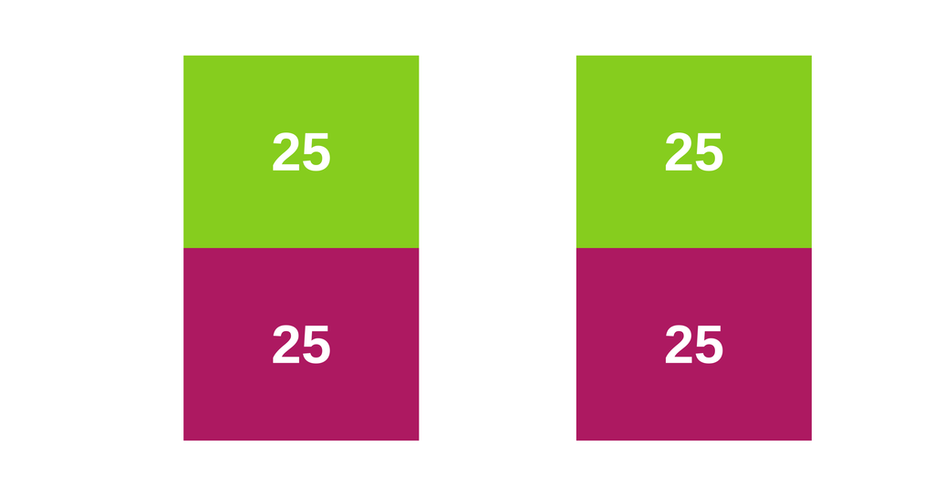

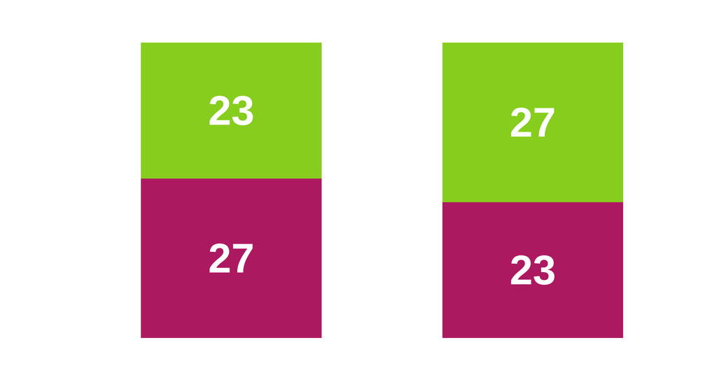

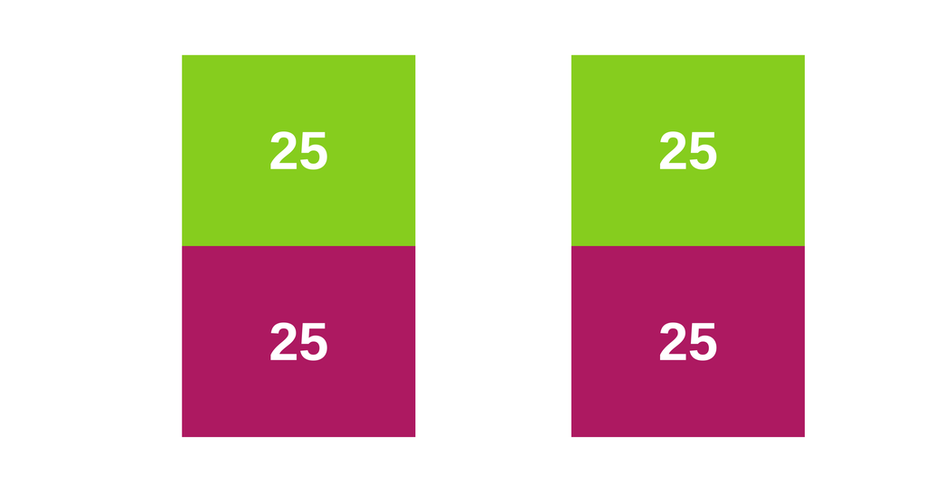

Even with equal group sizes (50/50), the purple/pink balance varies by chance across individual trials. Each experiment produces different compositions! But this is okay! On average we will be close to 50/50.

## Convergence Across Many Trials

**What happens when we run many random assignments?** (100 people, 50 purple/50 pink, groups of 50 each)

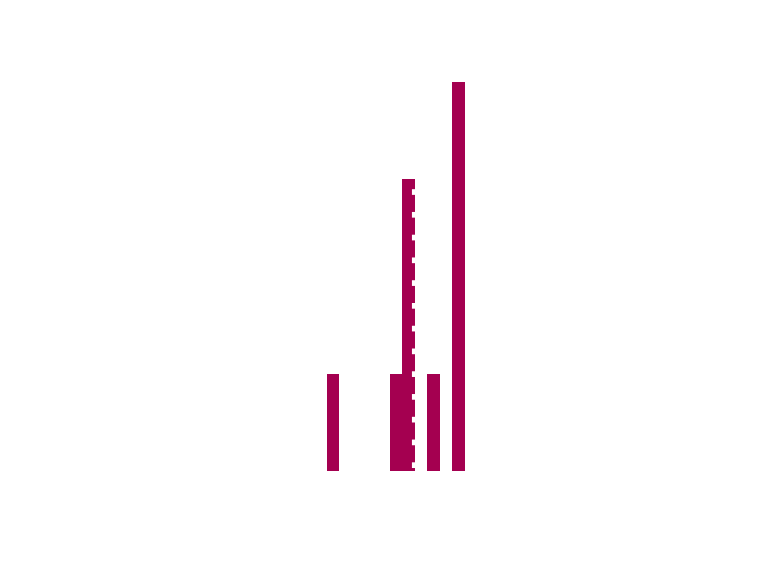

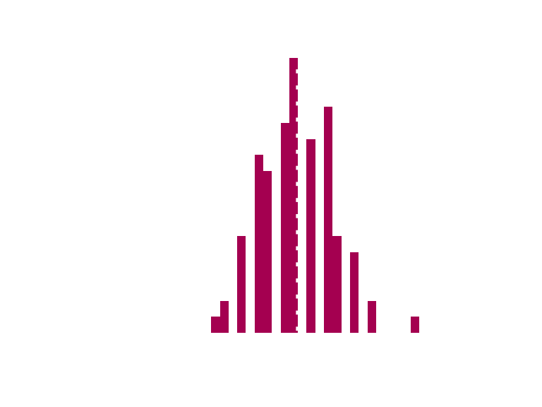

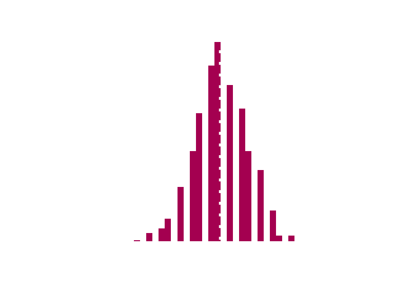

As we increase the number of trials, the distribution converges to the expected value (25 purple per group, dotted line). Random assignment creates characteristic balance *on average*!

## From Randomization to Sampling

The purple/pink simulations show chance variation when we randomly **assign** people to groups.

- **Sampling is the same process in disguise**: drawing a poll sample is randomly “assigning” people to the group we observe
- One sample = one trial: its result varies by chance
- Many samples = the convergence plot: results cluster predictably around the truth

Everything that follows about sampling uncertainty is the Law of Large Numbers you just saw — applied to polls instead of experiments.

## What 500 Samples Look Like

**The Issue**: We can never be 100% certain our sample perfectly represents the population

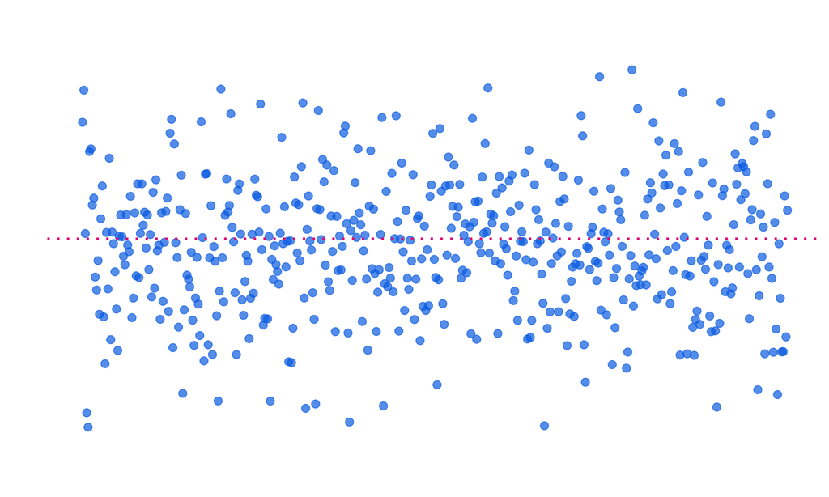

## Zooming Out (0–100 Scale)

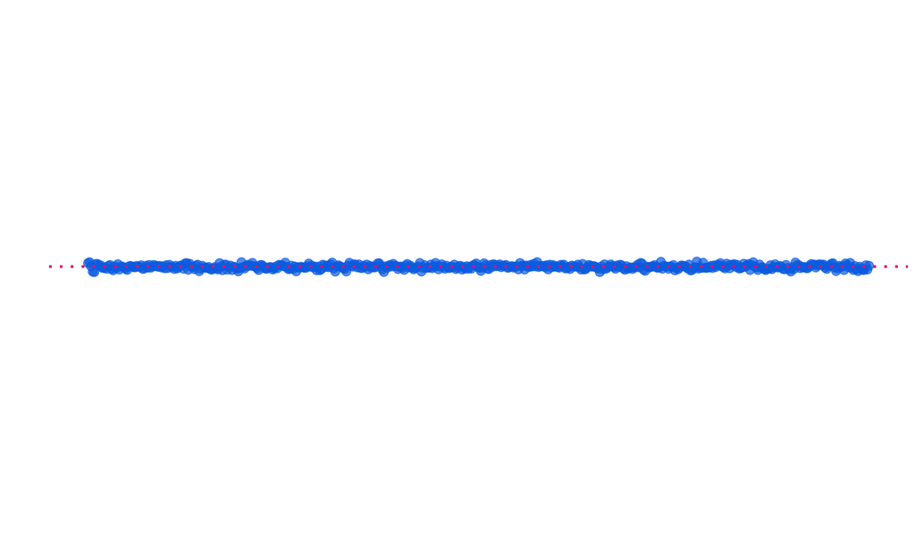

## The Sampling Distribution

**But there is a pattern.**

**The distribution of sample means is centered on the true population mean.**

- That is most estimates ($\bar{x}$) are close to the true population mean ($\mu$), though there are outliers

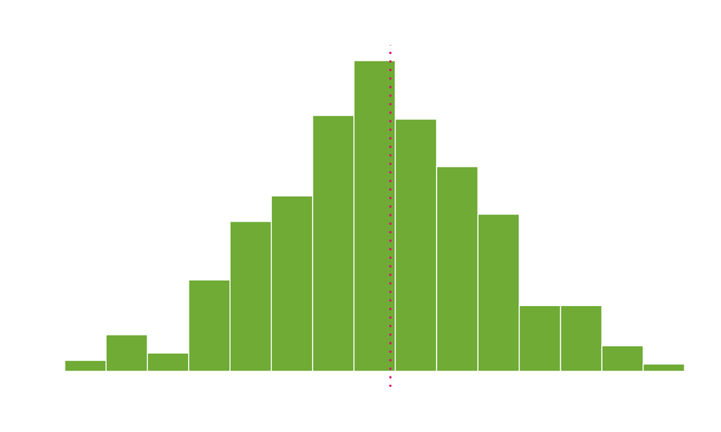

## Random Selection Is Fair

**If every sample gives a different result, why is there a pattern?** Because random sampling has predictable properties:

**Equal Probability of Selection**

- Each person in the population has an equal chance of being selected
- No systematic bias in who gets included

**Self-Correction Over Many Samples**

- Over many samples, this fairness averages out
- High values and low values tend to cancel each other out
- Sometimes we get slightly more high-approval people, sometimes more low-approval people
- But on average, we get a representative mix

## The Law of Large Numbers

**The Law of Large Numbers**

- With enough observations, extreme values become rare
- The average naturally gravitates toward the center
- Individual outliers have less influence in larger samples

**Example**:

- Flip a coin 10 times: might get 7 heads (70%)
- Flip a coin 1,000 times: very unlikely to get 700 heads (70%)
- The larger the sample, the closer we get to 50%
- *You watched this happen in the purple/pink simulations earlier today*

Larger samples give us more stable, reliable estimates that are closer to the true population value

## The Central Limit Theorem

The Central Limit Theorem states that:

- Sample means follow a normal (bell-shaped) distribution
- The center of this distribution is the true population mean (μ)
- This happens *regardless* of the shape of the population distribution

**What This Means**:

- Even if the population is skewed or oddly shaped, sample means will be normally distributed
- We can use the properties of the normal distribution to make inferences
- This is why we can calculate margins of error and confidence intervals

Randomness doesn’t mean chaos. Random sampling produces *predictable* patterns that we can quantify and use for inference.

Sample Size and Precision

## Why Pollsters Report Sample Size

Why do pollsters tell us about the size of their sample?

- Larger samples give us more precise estimates!

**Why?** More data points = less influence of random variation

## Standard Error

We know estimates vary predictably, and that larger samples vary less. We still need **one number** for the *typical* amount of variation — the **Standard Error**.

**Standard Error (SE)**: Measures how much our sample estimates vary from sample to sample

$$SE = \frac{\sigma}{\sqrt{n}}$$

- $\sigma$ = population standard deviation (often estimated using sample standard deviation $s$)
- $n$ = sample size

**Key Insights**:

- As $n$ increases, SE decreases
- SE tells us the “typical” distance between sample mean and population mean

**Demonstration**: Let’s see what happens as we increase sample size from 10 to 1,000

## Plugging In Numbers

**Given**: σ = 15, n = 100

$$SE = \frac{\sigma}{\sqrt{n}} = \frac{15}{\sqrt{100}} = \frac{15}{10} = 1.5$$

The typical sample mean will be about **1.5 points** away from the true population mean.

## Halving the Error Takes Four Times the Sample

| n | √n | SE = 15/√n |
| --- | --- | --- |
| 100 | 10 | **1.50** |
| 400 | 20 | **0.75** |
| 900 | 30 | **0.50** |
| 1,600 | 40 | **0.375** |

Precision gets expensive fast. This is why most national polls stop around n = 1,000.

## Sample Size Simulation: N = 10

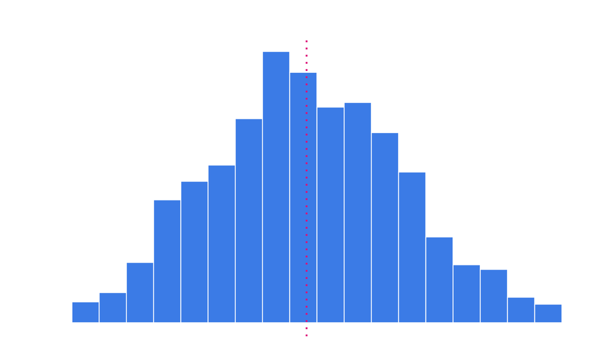

## Sample Size Simulation: N = 100

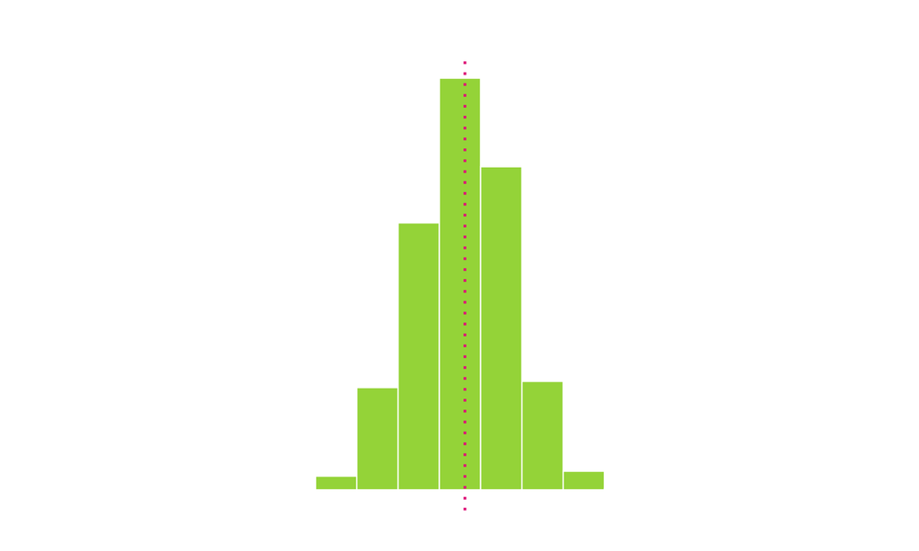

## Sample Size Simulation: N = 1,000

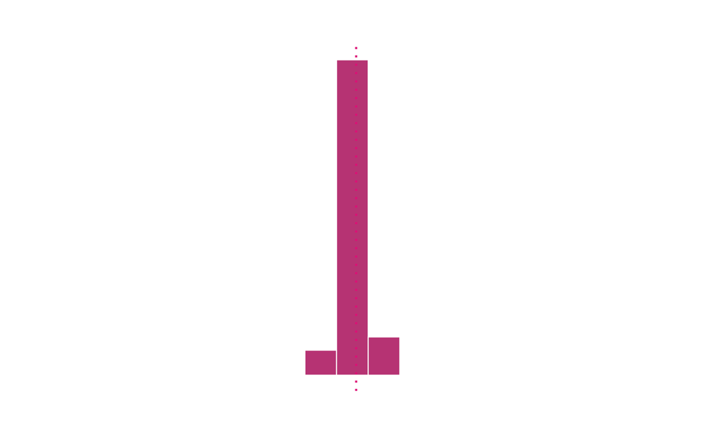

## How Standard Error Falls with Sample Size

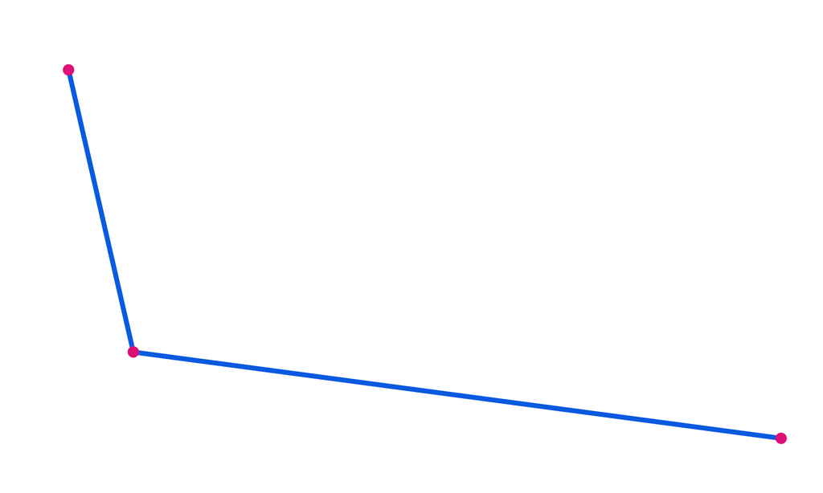

Margin of Error

## What is Margin of Error?

**How is this different from Standard Error?**

- **Standard Error**: Measures the typical variation in sample estimates
- **Margin of Error**: Converts standard error into a range

**Think of it this way**:

- Standard Error = “How much do sample means typically vary?”
- Margin of Error = “How far from our estimate might the true value be (with assumptions)?”

**Definition**: The range of values above and below our estimate within which the true population value likely falls

## The Formula

$$\text{MoE} = 1.96 \times SE = 1.96 \times \frac{\sigma}{\sqrt{n}}$$

The 1.96 comes from the normal distribution — it captures the middle 95% of possible outcomes.

“We’re 95% confident the true value is within ± MoE of our estimate”

## Calculating It

**A poll of 1,000 voters** (σ ≈ 15):

$$\text{MoE} = 1.96 \times \frac{15}{\sqrt{1000}} = 1.96 \times 0.47 = 0.93 \approx \pm 1\%$$

If the poll finds 52% approval → we’re 95% confident the true value is between **51%** and **53%**

When the news reports “margin of error ± 3%,” that’s almost always at 95% confidence. They rarely mention that 1 in 20 polls will have the true value outside this range — even when everything is done correctly.

## Margin of Error and Sample Size

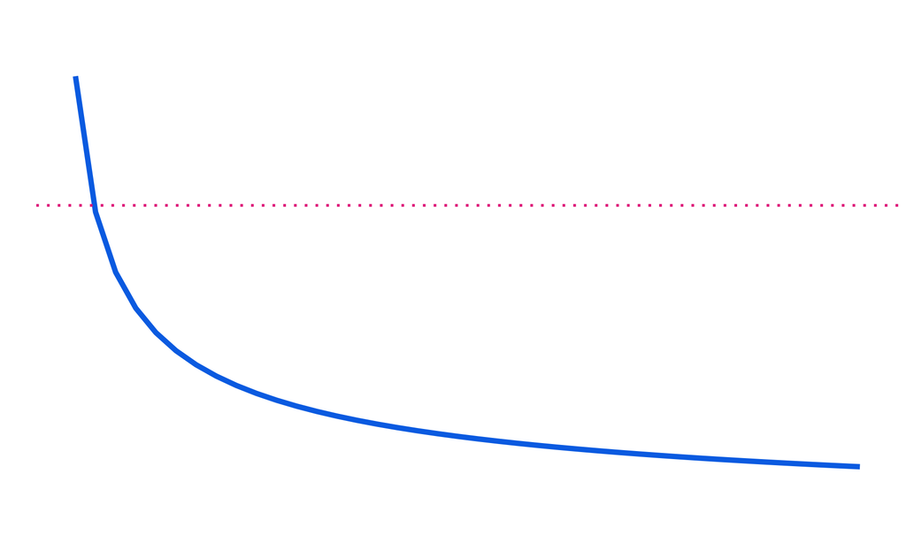

Putting It Together

## Example 1: Comparing Poll Precision

**Scenario**: Two polling firms survey voters the same week before an election. Both report Candidate A has 52% support.

**Poll 1** (Small local firm):

- Sample size: n = 100
- SE = 5%
- Candidate A’s true support is likely between 42% and 62%

**Poll 2** (Major national firm):

- Sample size: n = 1,000
- SE = 1.6%
- Candidate A’s true support is likely between 48.8% and 55.2%

## Same Estimate, Different Precision

**Same estimate (52%), very different conclusions**:

- Poll 1 tells us almost nothing — the candidate could be winning by a landslide OR losing badly
- Poll 2 gives us meaningful information — the candidate is probably ahead, but not by much

Without knowing the standard error, we can’t assess whether a poll result is informative or essentially useless

## Example 2: Evaluating a Policy Effect

**Scenario**: A researcher finds that a get-out-the-vote campaign increased turnout by 3 percentage points

**Study A**:

- Effect = 3% (SE = 0.5%)
- Effect is 6x larger than SE
- We’re quite confident there’s a real effect

**Study B**:

- Effect = 3% (SE = 4%)
- Effect is smaller than SE
- The effect might be zero or could be as large as 7%

## Why Study A Is Convincing and Study B Isn’t

**Same estimated effect (3%), very different confidence levels**

- Study A: Reliable finding — the effect is much larger than the noise
- Study B: Noisy estimate — the effect might disappear in replication

Standard error helps us distinguish between reliable findings and noisy estimates that might disappear in replication

## Detectable vs. Important

**Pair every estimate with an effect-size judgment.** A precise 0.1-point change is *detectable* but trivial; a noisy 5-point change is uncertain but potentially decisive.

When you read a result, ask both questions:

1. *Is the SE small enough that I should believe this estimate?* (statistical)
2. *Is the estimate large enough to matter for the decision at hand?* (practical)

Segment B takes up the statistical side — p-values and “significance” — and returns to this distinction at the end. (t-tests come next week.)

## Example 3: Election Night Coverage

**Scenario**: CNN reports: “Incumbent vote preference at 48% ± 3%”

**What This Tells Voters**:

- The true preference is likely between 45% and 51%
- We can’t say with confidence whether the president has majority support
- The race is essentially “too close to call”

## What Happens Without the ±

**Without margin of error**: People might think the president has exactly 48% support and make incorrect inferences

**With margin of error**: Citizens understand the result is uncertain and avoid overinterpreting

Margin of error prevents overinterpretation of poll results and helps citizens understand uncertainty in political information

## From Standard Errors to “Significance”

You now have the two core pieces of statistical inference:

- **Sampling distributions** — estimates vary from sample to sample
- **Standard errors** — a number for how *much* they vary

Segment B asks the money question: *is this estimate distinguishable from zero, or could it just be sampling noise?*

Answering that takes one more tool — a distribution invented to solve a very practical problem: brewing beer with small samples.

The t-Distribution

## William Sealy Gosset (1876-1937)

[figure not shown]

**The Guinness Problem (1908)**:

Gosset worked in the brewing laboratory testing beer quality. Each batch had slightly different characteristics: alcohol content, bitterness, etc.

**The business challenge**:

- Small samples: Testing meant destroying beer, so only a few bottles tested per batch
- High stakes: Bad batches had to be discarded (expensive!)
- Needed to know: Is this batch within acceptable quality standards?

## Gosset’s Statistical Problem

- Existing methods (z-tests) assumed you knew the *true* population standard deviation (σ)
- But Gosset only had small samples to estimate both the mean AND the standard deviation (s)
- When s is estimated from small samples, it’s unreliable—sometimes too small, sometimes too large

**Gosset’s insight**: We need to be more cautious (use wider confidence intervals) when we’re uncertain about the variability itself

**Published as “Student”** (Guinness policy forbade employees from publishing)

## The Problem with Small Samples

**With large samples**:

- Your estimate of standard deviation (s) is very close to the true value (σ)
- The normal distribution works fine

**With small samples**:

- Your estimate of standard deviation (s) can be quite far from the true value (σ)
- Sometimes you underestimate variability → overconfident conclusions
- Sometimes you overestimate variability → miss real effects

**Solution**: The t-distribution has heavier tails to account for this additional uncertainty

## The t-Distribution vs Normal Distribution

**Key Differences**:

- **Heavier tails**: More probability in extreme values
- **Shape depends on degrees of freedom (df)**: df = n - 1
- **Approaches normal as n increases**: At n > 30, they’re nearly identical

**Why heavier tails?**

- Small samples → the SD estimate itself is uncertain
- So extreme values are more plausible than the normal curve admits
- Result: a **higher bar** before calling an observation “extreme”

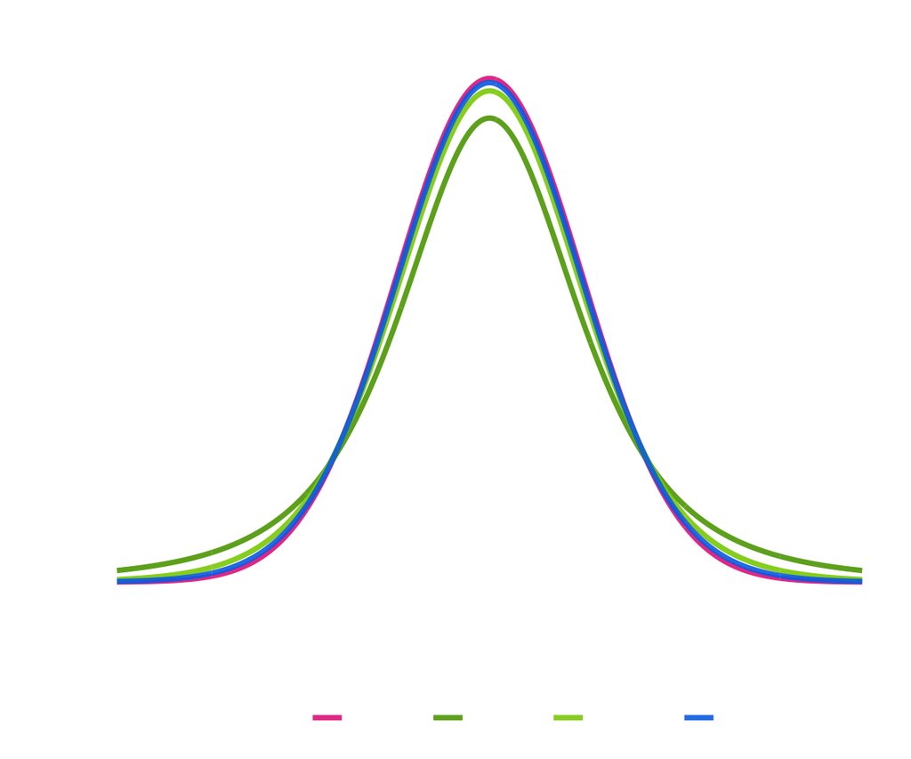

## Understanding Degrees of Freedom

**Degrees of freedom (df)**: The number of independent pieces of information available to estimate variability

**For a single sample**: df = n - 1

**Why subtract 1?**

Imagine you have 5 numbers that must average to 10. Once you know 4 of them (say: 8, 12, 9, 11), the 5th number is forced to be 10 (so the mean = 10). You only have 4 “free” choices—the 5th is determined.

**Key insight**: When estimating variability, you “use up” one degree of freedom calculating the mean first

## Critical Values: Setting the Bar for Significance

Next week you will compute **t-statistics** for real hypothesis tests. The critical value is the bar a t-statistic must clear.

**Critical value**: The t-statistic threshold that defines statistical significance

**How it works**: Compare your calculated t-statistic to the critical value - If |t| > critical value → **Reject H₀** (significant) - If |t| < critical value → **Fail to reject H₀** (not significant)

**Why critical values change with df**:

| df | Critical value (α=0.05, two-tailed) | What this means |
| --- | --- | --- |
| 5 | ±2.571 | Very high bar (small samples) |
| 10 | ±2.228 | High bar |
| 30 | ±2.042 | Moderate bar |
| ∞ | ±1.960 (normal) | Standard bar (large samples) |

**Practical implication**: With n=6 (df=5), you need t > 2.571 for significance. With n=100, you only need t > 1.98. Smaller samples require stronger evidence!

Segment B — What is Statistical Significance?

## Three Questions We Can’t Answer Yet

**The poll**: 500 voters — 52% support Candidate A, 48% support B. Is A *really* ahead, or is this sampling variability?

**The gender gap**: 200 men and 200 women — 65% vs. 55% support gun control. Real gap, or chance?

**The campaign ad**: 300 voters see the ad — turnout is 3% higher. Did it work, or is this random variation?

Without a systematic method, we’re just guessing. Hypothesis testing gives us that method.

Foundation: Understanding Variability

## SD vs. SE: Two Different Spreads

**Standard Deviation (SD)**

- Spread of individuals **within your sample**
- “How different are people from each other?”
- Survey 1,000 people: opinions span the scale, SD ≈ 25 points
- Does **not** shrink as n grows

**Standard Error (SE)**

- How far your **sample mean** likely sits from the **population mean**
- “How far off might my estimate be?”
- Same survey: SE = 25/√1000 ≈ 0.8 points
- **Shrinks** as n grows: SE = SD/√n

**SD describes your sample. SE describes the sample-to-population relationship.**

## Concrete Example: Voter Age

**Scenario**: You want to estimate the mean age of all voters in your state (the population)

**You take different sized samples**:

| Sample Size | Sample SD (approx) | SE = SD/√n | What SE tells you |
| --- | --- | --- | --- |
| n = 100 | ~15 years | 1.5 years | Sample mean likely ±1.5 years from population mean |
| n = 400 | ~15 years | 0.75 years | Sample mean likely ±0.75 years from population mean |
| n = 900 | ~15 years | 0.5 years | Sample mean likely ±0.5 years from population mean |

**Interpretation**:

- **SD (~15 years)**: In all samples, voter ages are spread out similarly. This describes variation within each sample.
- **SE (decreasing)**: Larger samples give estimates closer to the true population mean. SE quantifies how far your sample estimate is likely to be from the truth.

The Logic of Hypothesis Testing

## Is 55% Really Different From 50%?

Now that we understand uncertainty (SE), we can ask:

**“Is my result a sign that something real is happening?”**

**Example**: You poll 400 voters and find 55% support your candidate

- The SE is 2.5%
- Is 55% far enough from 50% to conclude your candidate is really ahead?
- Or could this easily happen by chance even if true support is exactly 50%?

## Why Direct Proof Is Impossible

**What we want to know**: “Is there really a gender gap in voting?”

**The problem**: We can’t prove this directly with sample data

**Why not?**: Even if no gender gap exists, we’ll almost never get exactly 50%-50% in our sample due to random variation

**The Solution**: Use proof by contradiction (like in mathematics)

## Ronald Fisher’s Solution

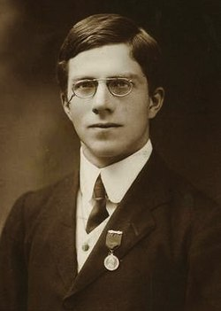

Ronald Fisher

**Ronald Fisher (1920s-1930s)**: Developed the framework we still use

Introduced a framework to test claims using proof by contradiction

**The Logic**:

1. Assume the opposite of what you want to show
2. See if the data makes that assumption look absurd
3. If it does, reject the assumption

This is exactly like mathematical proof by contradiction, but with probability instead of certainty

## Proof by Contradiction: A Simple Example

**Mathematical Example**: Prove √2 is irrational

1. Assume the opposite: √2 is rational
2. Show this leads to a logical contradiction
3. Therefore, our assumption must be false
4. Conclusion: √2 is irrational

**Fisher’s Statistical Version**:

1. Assume the opposite: No effect exists (null hypothesis)
2. Calculate: How likely is our data under this assumption?
3. If very unlikely: Reject the assumption
4. Conclusion: Evidence that an effect exists

## A Toy Example: Is the Coin Fair?

A friend hands you a coin and claims it’s fair. You flip it **10 times** and get **9 heads**.

- **Null ($H_0$)**: The coin is fair (P(heads) = 0.5)
- **Alternative ($H_1$)**: The coin is biased toward heads
- **Observed data**: 9 heads in 10 flips
- **p-value**: Probability of getting 9 or more heads if the coin were truly fair $\approx$ 0.011
- Under the null, this happens about **1% of the time** — unlikely enough to reject “fair coin”
- We never *proved* bias — we only showed that “fair” makes the data implausible

## Setting Up Hypotheses: The Framework

**For every research question, we set up two competing hypotheses**:

**Null Hypothesis ($H_0$)**: The “nothing is happening” hypothesis

- Usually states “no effect” or “no difference”
- This is what we assume to test by contradiction

**Alternative Hypothesis ($H_1$)**: What we think might be true

- States there is an effect or difference
- This is what we find evidence for by rejecting $H_0$

**Remember**: We never “prove” $H_1$. We only gather evidence against $H_0$.

## Example 1: Presidential Approval

**Research Question**: Has presidential approval dropped below 50%?

**Null Hypothesis ($H_0$)**: Approval = 50% (no drop)

**Alternative Hypothesis ($H_1$)**: Approval < 50% (has dropped)

**The Test**:

- Survey 1,000 voters, find 45% approval
- SE = 1.6%
- Question: Could we easily get 45% if true approval is really 50%?
- If very unlikely → reject $H_0$ → conclude approval has dropped

## Example 2: Gender Gap in Voting

**Research Question**: Do women and men differ in support for gun control?

**Null Hypothesis ($H_0$)**: No difference (men and women have equal support)

**Alternative Hypothesis ($H_1$)**: There is a difference

**The Test**:

- Survey 200 women (65% support) and 200 men (55% support)
- Difference = 10 percentage points
- Question: Could we easily get a 10-point difference if there’s really no gender gap?
- If very unlikely → reject $H_0$ → conclude a gender gap exists

Quantifying Evidence: P-values

## How Unlikely Is “Unlikely”?

We’ve established the logic: Reject $H_0$ if our data is very unlikely under the null hypothesis.

**But how do we measure “unlikely”?**

**This is where p-values come in.**

## What Is a P-value?

**P-value**: The probability of getting a result as extreme as ours (or more extreme) if the null hypothesis is true

**So**:

- “If the null hypothesis is true” = assuming no real effect exists
- “As extreme as ours or more extreme” = our result or anything further from what $H_0$ predicts (e.g., if we observed +0.5 SD, we count that *and* +0.6, +0.7, … further out in the tail)
- “Probability” = how often we’d see this just by chance

## P-value: Concrete Example 1

**Scenario**: Presidential approval poll

- $H_0$: True approval = 50%
- We survey 1,000 people, find 45% approval
- SE = 1.6%

**Question**: If true approval really is 50%, what’s the probability we’d get 45% or lower just by chance?

**Answer**: p = 0.002 (very small!)

**Interpretation**: Only 0.2% chance of seeing 45% or lower if true approval is actually 50%. This is strong evidence against $H_0$.

## P-value: Concrete Example 2

**Scenario**: Gender gap in gun control

- $H_0$: No difference between men and women
- Survey: 65% of women support, 55% of men support
- Difference = 10 percentage points

**Question**: If there’s really no gender gap, what’s the probability we’d see a 10-point difference (or larger) just by chance?

**Answer**: p = 0.03

**Interpretation**: 3% chance of seeing a difference this large if there’s really no gender gap. This suggests a real difference exists.

## The 0.05 Convention

We need a rule for when to reject $H_0$.

**Convention**: Use α = 0.05 as the threshold

**Decision Rule**:

- If p < 0.05: Reject $H_0$ (result is “statistically significant”)
- If p ≥ 0.05: Fail to reject $H_0$ (result is “not statistically significant”)

**What α = 0.05 means**: We’re willing to reject $H_0$ when there’s less than a 5% chance our result is due to random variation

## Applying the 0.05 Rule

| Example | P-value | Decision | Interpretation |
| --- | --- | --- | --- |
| Approval poll | p = 0.002 | Reject $H_0$ | Strong evidence approval ≠ 50% |
| Gender gap | p = 0.03 | Reject $H_0$ | Evidence of real gender gap |
| Campaign ad | p = 0.25 | Fail to reject | Insufficient evidence ad works |
| Turnout study | p = 0.048 | Reject $H_0$ | Evidence of effect (barely) |
| Policy effect | p = 0.052 | Fail to reject | Insufficient evidence (barely) |

**Notice**: The difference between p = 0.048 and p = 0.052 is tiny, but we treat them very differently!

Understanding What P-values Mean (and Don’t Mean)

## What a P-value Does Tell You

**P-value = Probability of seeing data this extreme IF the null hypothesis is true**

**Yes**: “Assuming no real effect, there’s a 3% chance of seeing a difference this large”

**Yes**: “Our data would be quite unlikely if the null hypothesis were true”

**Yes**: “This p-value provides evidence against the null hypothesis”

## Interpreting p = 0.02 Correctly

**Study**: Gender gap in voting preferences

**Finding**: Women 12 points more Democratic than men, p = 0.02

**Yes — the correct reading**:

“If there were really no gender gap in the population, we would see a difference of 12 points or larger only 2% of the time. Since this is unlikely, we have evidence that a real gender gap exists.”

## What a P-value Does Not Tell You

The most common mistake students make: Thinking the p-value tells you the probability that $H_0$ is true.

**IT DOES NOT!**

**P-value answers**: “How likely is my data if $H_0$ is true?”

**P-value does NOT answer**: “How likely is $H_0$ given my data?”

These are different questions!

## About the Data, Not the Hypothesis

**Example**: You find p = 0.04

**No**: “There’s a 4% chance the null hypothesis is true”

**Yes**: “If the null hypothesis were true, there’s a 4% chance of seeing data this extreme”

**The difference**:

- P-value assumes $H_0$ is true, then asks about the data
- We want to know about $H_0$ given the data
- These are logically different!

## Common Misinterpretations

| What You Might Say | Why It’s Wrong | What You Should Say |
| --- | --- | --- |
| “There’s a 5% chance $H_0$ is true” | P-value doesn’t tell you probability of hypotheses | “If $H_0$ were true, this result would occur 5% of the time” |
| “There’s a 95% chance $H_1$ is true” | P-value says nothing about $H_1$ | “We have evidence against $H_0$” |
| “We proved the effect exists” | We never prove anything with stats | “We found statistically significant evidence for an effect” |
| “We accept $H_0$” | Failure to reject ≠ acceptance | “We fail to reject $H_0$” |

Statistical vs Practical Significance

## Two Different Questions

**Statistical Significance**: “Is this effect unlikely to be due to chance?”

- Answers: “Is it real?”
- Measured by: p-value

**Practical Significance**: “Is this effect large enough to matter?”

- Answers: “Is it important?”
- Measured by: effect size

**A result can be statistically significant but practically meaningless, or vice versa!**

## Example 1: Statistically Significant but Trivial

**Study**: Effect of new campaign strategy on vote share

**Sample size**: 50,000 voters surveyed

**Finding**:

- Control group: 50.0% support
- Treatment group: 50.3% support
- Difference: 0.3 percentage points
- p = 0.001 (highly significant!)

**Interpretation**: Statistically significant? Yes · Practically meaningful? No — a real but trivial effect

**Why**: with n = 50,000 the SE shrinks until even a fraction of a point is detectable. Large samples make *tiny* effects “significant” — always pair the p-value with the effect size.

## Example 2: Large Effect but Not Significant

**Study**: New voter mobilization program

**Sample size**: 40 voters

**Finding**:

- Control group: 40% turnout
- Treatment group: 65% turnout
- Difference: 25 percentage points
- p = 0.12 (not significant)

**Interpretation**:

- Statistically significant? No — could be due to chance with this small sample
- Practically important? Yes — a 25-point increase in turnout would be massive
- **Conclusion**: Need larger study to confirm, but hints at important effect

## Example 3: Both Significant and Meaningful

**Study**: Gender gap in congressional approval

**Sample size**: 1,500 (750 men, 750 women)

**Finding**:

- Men: 35% approval
- Women: 50% approval
- Difference: 15 percentage points
- p = 0.001

**Interpretation**:

- Statistically significant? Yes — very unlikely by chance
- Practically important? Yes — a 15-point gap matters for understanding public opinion
- **Conclusion**: Real and meaningful gender gap

## What You Should Always Report

When reporting results, ALWAYS include:

1. **The effect size** (e.g., “12 percentage point difference”)
2. **The p-value** (e.g., “p = 0.03”)
3. **Sample size** (e.g., “n = 400”)

**Good reporting**: “Women supported the policy 12 percentage points more than men (65% vs 53%, n = 400, p = 0.03)”

**Bad reporting**: “The difference was significant (p < 0.05)”

**Remember**: Statistical significance tells you if an effect is real. Effect size tells you if it matters. You need both!

## Key Takeaways

After this week you can:

- Explain why estimates vary from sample to sample — and why that variation is predictable
- Read a poll’s margin of error, and compute SE = SD/√n (halving the error takes 4× the sample)
- Explain what the t-distribution adds for small samples (heavier tails, df = n − 1)
- State null and alternative hypotheses and interpret a p-value without overclaiming
- Distinguish statistical significance from practical importance — and insist on both

Looking Ahead

## In Our Next Class

**Statistical Tests**

- One-sample and two-sample t-tests
- Testing regression coefficients
- From p-values to substantive conclusions